# Populism, the 5G conspiracy and direct action

Matteo Tiratelli

07/01/2021

## Towards a differentiated understanding of "populism"

The term "populism" can be a frustrating one. It is more often used as an insult than an analytic description (D'Eramo 2013, 2017). Its transference from Latin America's 'pink wave' of socialist and pro-indigenous movements to the anti-migrant right in the Global North seems designed to generate more heat than light (e.g. Oliver and Rahn 2016). And its relationship to older efforts to demarcate the "proper" limits of democracy have yet to be thought through in any depth (c.f. Laclau 2005).

In the UK, popular support for leaving the European Union (Brexit) is often described as a form of "populism". But so too are conspiracy theories, Covid- and climate-denial and a range of more extreme racist and anti-migrant political beliefs (Silva et al 2017, Bergmann 2018, Lewis et al 2019). There is an important ideological sleight of hand here. The widespread (although possibly inaccurate) narrative that British populism is a phenomenon of the white working class, the post-industrial "left behind" (Bhambra 2017, Chan et al 2020), is based studies of fairly popular political positions like opposition to the European Union. When those broad movements are placed in the same category as more extreme white supremacist or conspiratorial forms of politics, the implication is that explanations of one will suffice as explanations of the other. In this case, the assumption is that conspiracy theories or Covid-denialism are also the product of post-industrial decline.

Disentangling these various levels of British "populism" therefore remains a challenge. This short note attempts to do this at the ecological level, assessing how similar the geographic patterns of different forms of "populism" really are. Figure 1 shows the extent of support for the Brexit Party (led by that populist par excellence, Nigel Farrage) across Britain in the 2019 European Parliament elections. With the exceptions of London and Scotland, most British regions showed fairly high levels of support for the Brexit Party, with Wales and the North West having the lowest levels of support.

Figure 1: Support for the Brexit Party in the 2019 European Elections by region

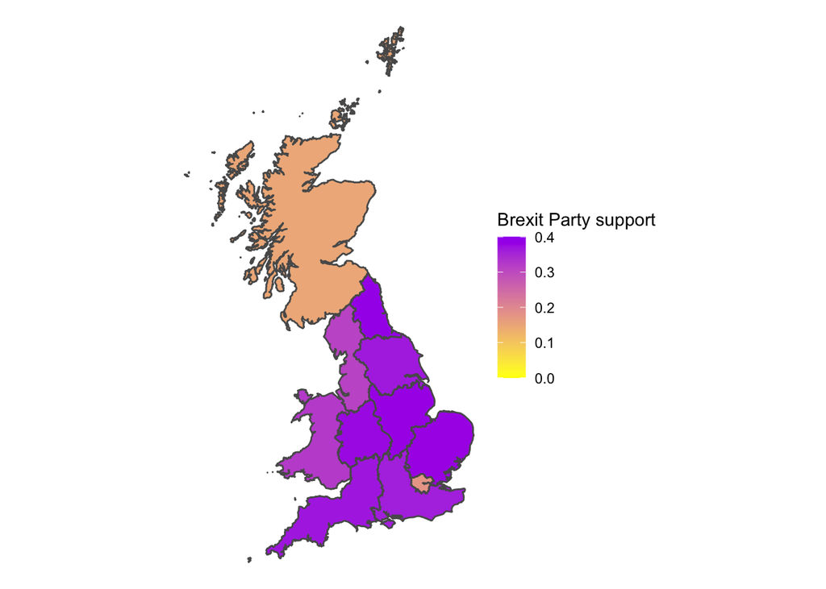

The second form of "populism" was chosen to maximise differences: attacks on 5G masts after the outbreak of Covid-19. In the first months of 2020, a conspiracy started to circulate suggesting that the new coronavirus was in fact caused by new 5G communications technology. In early March, a video by the American holistic medical practioner Thomas Cowan went viral after it was shared by celebrities including Woody Harrelson, John Cusack, and singer Keri Hilson, and other high-profile conspiracists such as Mark Steele and David Icke. These theories spread rapidly through social media (particularly YouTube) and had material consequences in terms of people's willingness to engage in Covid-19 health-protective behaviours (Allington et al 2020). But this also led to a more political response: direct action aimed at destroying 5G masts and other telecommunications infrastructure. Ofcom collected records of these attacks from March 2020, and they form the basis of the graphs below (figures 2 and 3). It is worth noting that they have no data from earlier periods to compare against, nor would they release the locations of telecommunication infrastructure because of fears of further attacks. These methodological limitations are significant.

Figure 2: The number of attacks on communications infrastructure in 2020

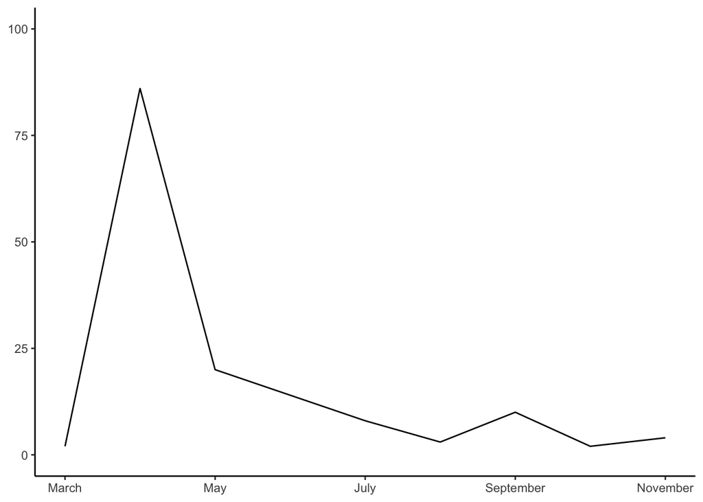

Figure 3: Attacks on communications infrastructure in 2020 by region

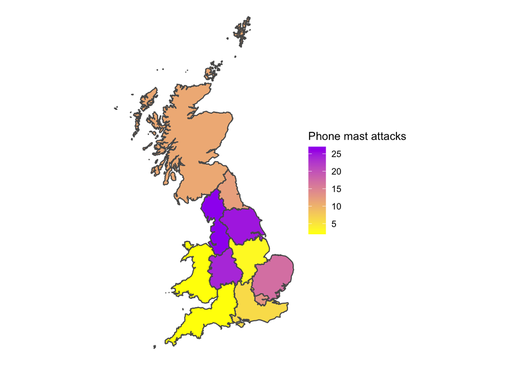

Looking at the level of counties (the smallest geographic areas for which data was available), attacks were most common in Merseyside, West Yorkshire and the West Midlands. Taken together, those three areas account for 42% of all attacks, but again, none of them are particularly "populist". Merseyside has been a Labour stronghold for over two decades, and indeed only recorded 26% support for the Brexit Party in 2019 (well below the average of 33%). Support for the Brexit Party in both West Yorkshire and the West Midlands actually perfectly mirrored the English average of 33%.

So if the geographies of different forms of "populism" are different, then where does that leave the term itself? Clearly this is not enough evidence on which to dismiss it entirely and one explanation for these discrepancies may be that dramatic events shift the underlying distribution of "populist" ideas and actions (Frey 2020). Another is that participants in illegal direct action often have unusual and surprising backgrounds, which may not reflect the broader constituency from which a political group gains its support (e.g. Gambetta and Hertog 2016). Nevertheless, these questions and discrepancies favour a disaggregated approach to the study of "populism", one which clearly distinguishes it from other related phenomenon and which doesn't treat it as some homogeneous monstrosity "running riot" across Britain that needs to be defeated at all costs (the quote and sentiment are from former British Prime Minister Tony Blair - BBC 2018, 2019).

### Bibliography

- Allington, Daniel, Bobby Duffy, Simon Wessely, Nayana Dhavan, and James Rubin. ‘Health-Protective Behaviour, Social Media Usage and Conspiracy Belief during the COVID-19 Public Health Emergency’. Psychological Medicine (2020): 1–7.
- BBC. BBC Politics on Twitter: "Tony Blair Says Populism Is ‘Running Riot’ in the UK, 2019. https://twitter.com/bbcpolitics/status/1198980253722517504?lang=en.
- ———. Tony Blair on Brexit, Labour, and Populism - BBC Newsnight, 2018. https://www.youtube.com/watch?list=PLJxnQXiytA_QCqZIXndSNLD_1hTzLBCsD&v=63TBWCnlPO8.
- Bergmann, Eirikur. Conspiracy & Populism: The Politics of Misinformation. Springer, 2018.
- Bhambra, Gurminder K. ‘Brexit, Trump, and “Methodological Whiteness”: On the Misrecognition of Race and Class’. The British Journal of Sociology 68, no. S1 (2017): S214–32.
- Chan, Tak Wing, Morag Henderson, Maria Sironi, and Juta Kawalerowicz. ‘Understanding the Social and Cultural Bases of Brexit’. The British Journal of Sociology 71, no. 5 (2020): 830–51.
- D’Eramo, Marco. ‘Populism and the New Oligarchy’. New Left Review, no. 82 (2013): 5–28.
- ———. ‘They, The People’. New Left Review, no. 103 (2017): 129–38.
- Frey, Arun. ‘“Cologne Changed Everything”—The Effect of Threatening Events on the Frequency and Distribution of Intergroup Conflict in Germany’. European Sociological Review 36, no. 5 (1 October 2020): 684–99.
- Gambetta, Diego, and Steffen Hertog. Engineers of Jihad: The Curious Connection between Violent Extremism and Education. Princeton: Princeton University Press, 2016.
- Laclau, Ernesto. On Populist Reason. Verso, 2005.
- Lewis, Paul, Sarah Boseley, and Pamela Duncan. ‘Revealed: Populists Far More Likely to Believe in Conspiracy Theories’. The Guardian, 1 May 2019, sec. World news. https://www.theguardian.com/world/2019/may/01/revealed-populists-more-likely-believe-conspiracy-theories-vaccines.
- Oliver, J. Eric, and Wendy M. Rahn. ‘Rise of the Trumpenvolk: Populism in the 2016 Election’. The ANNALS of the American Academy of Political and Social Science 667, no. 1 (1 September 2016): 189–206.
- Silva, Bruno Castanho, Federico Vegetti, and Levente Littvay. ‘The Elite Is Up to Something: Exploring the Relation Between Populism and Belief in Conspiracy Theories’. Swiss Political Science Review 23, no. 4 (2017): 423–43.